# Emote Pipeline Demo

# Reading in EMOTE Data

The Emote dataset is described in the EMOTE folder on the psychology shared drive. To extract IBI, we wrote a python function to pull IBI from the zip files and concatenate each participant’s sessions. The result is one .csv per participant, which is read into a tibble/dataframe as follows:

```r
# Note: we read this in from the psychology shared drive
example_ibi_file = "/Volumes/psychology/Shared/WEACT/EMOTE/TT_Analysis/watch_data/IBI_participant_207.csv"
example_ibi_file = fread(example_ibi_file)
```

```
|--------------------------------------------------|
|==================================================|
```

```r
head(example_ibi_file)
```

| Beat_Time | Beat_Interval | Session_Start_GMT |
| --- | --- | --- |
| 13.07872 | 0.734409 | 1489773100 |
| 21035.71290 | 0.625029 | 1489773100 |
| 21036.32230 | 0.609403 | 1489773100 |
| 21041.30690 | 0.718783 | 1489773100 |
| 21041.90068 | 0.593777 | 1489773100 |
| 21042.57259 | 0.671906 | 1489773100 |

```r
example_ibi_file = example_ibi_file%>%
  as_tibble()%>%
  # create new variables with mutate() and lubridate package
  mutate(Beat = as_datetime(Beat_Time+Session_Start_GMT, tz = "GMT"),
           Session_Start_GMT = as_datetime(Session_Start_GMT),
           Beat2 = as.numeric(Beat) - as.numeric(Session_Start_GMT[1]),
           ID = 207)%>%
  arrange(Beat)
head(example_ibi_file)
```

| Beat_Time | Beat_Interval | Session_Start_GMT | Beat | Beat2 | ID |
| --- | --- | --- | --- | --- | --- |
| 13.07872 | 0.734409 | 2017-03-17 17:51:40 | 2017-03-17 17:51:53 | 13.07872 | 207 |
| 13.79751 | 0.718783 | 2017-03-17 17:51:40 | 2017-03-17 17:51:53 | 13.79751 | 207 |
| 14.45379 | 0.656280 | 2017-03-17 17:51:40 | 2017-03-17 17:51:54 | 14.45379 | 207 |
| 15.17257 | 0.718783 | 2017-03-17 17:51:40 | 2017-03-17 17:51:55 | 15.17257 | 207 |
| 15.86010 | 0.687531 | 2017-03-17 17:51:40 | 2017-03-17 17:51:55 | 15.86010 | 207 |
| 16.53201 | 0.671906 | 2017-03-17 17:51:40 | 2017-03-17 17:51:56 | 16.53201 | 207 |

We read them all into one grouped dataframe in a loop:

```r
# first, list all of the available files
# Note: we read this in from the psychology shared drive
participants_csv_list = list.files("/Volumes/psychology/Shared/WEACT/EMOTE/TT_Analysis/watch_data")%>%
  grep(pattern = "*.csv", x=., value = TRUE)
# initialise empty list
participants = list()
# loop through the files
for(x in 1:length(participants_csv_list)){
  participants[[x]] = fread(paste0("/Volumes/psychology/Shared/WEACT/EMOTE/TT_Analysis/watch_data/", participants_csv_list[x]))%>%
    as_tibble()

  participants[[x]] = participants[[x]]%>%
    mutate(Beat = as_datetime(Beat_Time+Session_Start_GMT, tz = "GMT"),
           Session_Start_GMT = as_datetime(Session_Start_GMT),
           Beat2 = as.numeric(Beat) - as.numeric(Session_Start_GMT[1]),
           ID = as.numeric(gsub(pattern = "\\D", replacement =  "", x = participants_csv_list[x])))%>%
    arrange(Beat)
}
```

[output not shown]

```r
ibi_data = bind_rows(participants)
head(ibi_data)
```

| Beat_Time | Beat_Interval | Session_Start_GMT | Beat | Beat2 | ID |
| --- | --- | --- | --- | --- | --- |
| 26.93873 | 0.843789 | 2016-12-22 22:06:02 | 2016-12-22 22:06:28 | 26.93873 | 200 |
| 27.78252 | 0.843789 | 2016-12-22 22:06:02 | 2016-12-22 22:06:29 | 27.78252 | 200 |
| 28.64194 | 0.859414 | 2016-12-22 22:06:02 | 2016-12-22 22:06:30 | 28.64194 | 200 |
| 29.43885 | 0.796911 | 2016-12-22 22:06:02 | 2016-12-22 22:06:31 | 29.43885 | 200 |
| 30.34514 | 0.906291 | 2016-12-22 22:06:02 | 2016-12-22 22:06:32 | 30.34514 | 200 |
| 31.26706 | 0.921917 | 2016-12-22 22:06:02 | 2016-12-22 22:06:33 | 31.26706 | 200 |

There is not much data cleaning required as RHRV takes care of most of this. RHRV reads in a vector of beats, where each beat is the offset in seconds from time = 0. This is why we add the columns `Beat2` and `Session_Start_GMT`, so that we can have one continuous vector of beats for one participant csv:

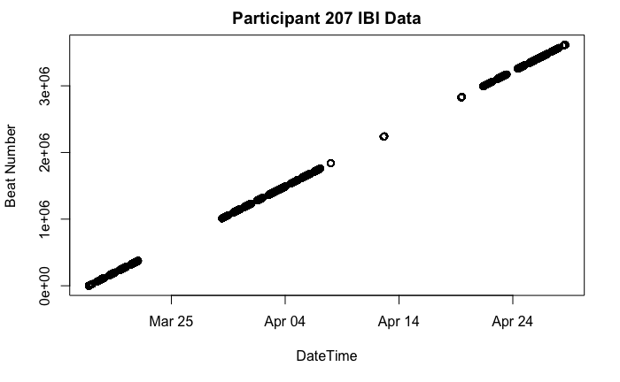

```r
ibi_data%>%
  filter(ID == 207)%>%
  select(Beat, Beat2)%>%
  plot(main = "Participant 207 IBI Data", xlab = "DateTime", ylab = "Beat Number")
```

As you can see, each beat is offset from the initial start time of t=0.

The labels for classification are given by surveys, which are also accessible in the EMOTE folder. These surveys are self-reported and come with timestamps for the survey time or eating episode time. Timestamps for eating episode had to be adjusted by hand, so the surveys file is static and should not be edited.

```r
# Note: we read this in from the psychology shared drive
surveys = read_excel("/Volumes/psychology/Shared/WEACT/EMOTE/TT_Analysis/Participants/UpdatedSurveys_180713.xlsx")
head(surveys)
```

| ID | when | EmotionalEatingEpisodes | Event | Stress | Please rate your current level of hunger: | Urge to eat | Calm | Sad | Distressed | Happy | Angry | Irritable | Ashamed | Lonely | Disgusted | Bored | Nervous | Confident | Anxious | Guilt |
| --- | --- | --- | --- | --- | --- | --- | --- | --- | --- | --- | --- | --- | --- | --- | --- | --- | --- | --- | --- | --- |
| 228 | 2018/04/09 01:56:16+0000 | 2 | 2018/04/09 01:56:16+0000 | 4 | 1 | 2 | 0 | 1 | 0 | 0 | 0 | 0 | 1 | 1 | 0 | 0 | 0 | 0 | 1 | 1 |
| 205 | 2017/02/22 22:43:56+0000 | NA | 2017/02/22 22:43:56+0000 | NA | NA | NA | 0 | 0 | 0 | 0 | 0 | 0 | 0 | 0 | 0 | 0 | 0 | 0 | 0 | 0 |
| 205 | 2017/02/23 01:11:17+0000 | 2 | 2017/02/23 01:11:17+0000 | 5 | 5 | 5 | 0 | 0 | 1 | 0 | 0 | 0 | 0 | 0 | 0 | 0 | 1 | 0 | 0 | 0 |
| 205 | 2017/02/23 00:09:38+0000 | 2 | 2017/02/23 00:09:38+0000 | 5 | 5 | 5 | 0 | 0 | 1 | 0 | 0 | 0 | 0 | 0 | 0 | 0 | 1 | 0 | 0 | 0 |
| 205 | 2017/02/23 13:47:39+0000 | 2 | 2017/02/23 13:47:39+0000 | 2 | 4 | 4 | 1 | 0 | 0 | 0 | 0 | 0 | 0 | 0 | 0 | 0 | 0 | 0 | 0 | 0 |
| 205 | 2017/02/23 13:48:00+0000 | 2 | 2017/02/23 13:48:00+0000 | 2 | 4 | 3 | 1 | 0 | 0 | 0 | 0 | 0 | 0 | 0 | 0 | 0 | 0 | 0 | 0 | 0 |

```r
# read in the surveys and clean with lubridate
surveys = surveys%>%
  mutate(when = ymd_hms(when),
         Y = factor(ifelse(EmotionalEatingEpisodes == 1 | EmotionalEatingEpisodes == 3, "Episode", "Control")),
         Event = ymd_hms(Event))%>%
  select(ID:Stress, Y, -EmotionalEatingEpisodes)%>%
  filter(complete.cases(.))%>%
  arrange(ID, when)
head(surveys)
```

| ID | when | Event | Stress | Y |
| --- | --- | --- | --- | --- |
| 200 | 2016-12-22 23:29:35 | 2016-12-22 23:29:35 | 2 | Control |
| 200 | 2016-12-23 01:28:47 | 2016-12-23 01:28:47 | 1 | Control |
| 200 | 2016-12-23 13:44:13 | 2016-12-23 13:44:13 | 2 | Control |
| 200 | 2016-12-23 15:27:36 | 2016-12-23 15:27:36 | 1 | Control |
| 200 | 2016-12-23 18:17:50 | 2016-12-23 18:17:50 | 1 | Control |
| 200 | 2016-12-23 20:19:34 | 2016-12-23 20:19:34 | 3 | Control |